# Thymus ATAC-seq preprocessing and EDA

```r
suppressPackageStartupMessages({
library(Seurat)
library(tidyverse)
library(SingleCellExperiment)
library(scater)
library(pbapply)
library(future)
library(reshape2)
library(ggpubr)
library(UpSetR)
})

source("~/multiOmic_benchmark/selectFeatures.R")
```

Load F74 datasets (preprocessed as in `makeSCElist.r`). Includes raw and processed ATAC-seq and RNA-seq dataset. ATAC-seq data was reduced to gene level features as in Seurat pipeline.

```r
f74.sce.list <- readRDS("~/my_data/integrated_thymus/F74_SCElist_20191017.RDS")
f74.atac <- f74.sce.list$ATAC
f74.rna <- f74.sce.list$RNA
```

## Feature selection

Compare betwen HVGs from ATAC and HVGs from RNA (i.e. genes used for cell type annotation)

```r
n_features = 4000
hvg.rna <- HVG_Seurat(f74.sce.list[["RNA"]], nfeatures = n_features) %>% {.[. %in% rownames(f74.sce.list[["ATAC"]])]}
hvg.atac <- HVG_Seurat(f74.atac, nfeatures = length(hvg.rna))

upset(fromList(list(hvg.rna=hvg.rna, hvg.atac=hvg.atac)))
```

## Dimensionality Reduction

```r
f74.atac.seu <- as.Seurat(f74.atac, verbose=FALSE)
f74.atac.seu <- ScaleData(f74.atac.seu, do.center = TRUE, verbose=FALSE)
f74.atac.seu <- RunPCA(f74.atac.seu, features = hvg.rna, verbose=FALSE)
f74.atac.seu <- RunUMAP(f74.atac.seu, reduction = "pca", dims=1:30, verbose=FALSE)

DimPlot(f74.atac.seu, reduction = "umap", group.by = NULL) + ggtitle("scRNA-seq HVGs")
```

## Clustering

```r
f74.atac.seu <- FindNeighbors(f74.atac.seu, verbose = F)
f74.atac.seu <- FindClusters(f74.atac.seu, algorithm = 4, verbose = F)

DimPlot(f74.atac.seu, reduction = "umap", group.by = 'ident') + ggtitle("leiden") +
  ggsave("~/multiOmic_benchmark/output/ATAC_EDA/ATAC_hvg_clustering.jpeg", height = 6, width=8)
```

## Accessibility of thymic markers

Provided by Cecilia

```r
FeaturePlot(f74.atac.seu, features = c('PTPRC','CD4','CD8A','CD8B','CD79A','FOXN1','EPCAM','PDGFRA','GNG4', 'FOXP3','RAG1','RAG2','PTCRA','IL7R','NKG7','CCR7')) +
  ggsave("~/output/ATAC_EDA/ATAC_hvg_markers.jpeg", height = 15, width=15)
```

## Co-accessibility of markers

Genes that are distinctive of the same clusters will tend to be co-expressed in the same cells. Hence, to test if marker genes show patterning also in accessibility, I calculate correlation of accessibility profiles of thymus development marker genes and compare co-accessibility with their correlation in gene expression.

```r
markers <- c('PTPRC','CD4','CD8A','CD8B','CD79A','FOXN1','EPCAM','PDGFRA','GNG4',
             'FOXP3','RAG1','RAG2','PTCRA','IL7R','NKG7','CCR7')
markers <- intersect(markers, rownames(f74.atac.seu@assays$RNA@counts))

## Calculate co-accessibility of marker genes
marker.cormat.atac <-
  f74.atac.seu@assays$RNA@scale.data[markers,] %>%
  as.matrix() %>%
  t() %>%
  cor(use="pairwise.complete.obs")

## Same on RNA
f74.rna.seu <- as.Seurat(f74.rna)
f74.rna.seu <- ScaleData(f74.rna.seu)
marker.cormat.rna <-
  f74.rna.seu@assays$RNA@scale.data[markers,] %>%
  as.matrix() %>%
  t() %>%
  cor(use="pairwise.complete.obs")
```

```r
png("~/multiOmic_benchmark/output/ATAC_EDA/ATAC_hvg_coaccessibility.png", height=500, width=500)
pheatmap::pheatmap(marker.cormat.atac, main="co-accessibility", cellwidth = 20, cellheight = 20)
dev.off()
png("~/multiOmic_benchmark/output/ATAC_EDA/ATAC_hvg_coexpression.png", height=500, width=500)
pheatmap::pheatmap(marker.cormat.rna, main="co-expression", cellwidth = 20, cellheight = 20)
dev.off()
```

```r
long.cormat.atac <-
  melt(marker.cormat.atac, value.name = "cor.accessibility") %>%
  distinct(cor.accessibility, .keep_all = T) %>%
  unite("pair", c("Var1", "Var2"))

long.cormat.rna <-
  melt(marker.cormat.rna, value.name = "cor.gex") %>%
  distinct(cor.gex, .keep_all = T) %>%
  unite("pair", c("Var1", "Var2"))


full_join(long.cormat.atac, long.cormat.rna) %>%
  dplyr::filter(cor.accessibility!=1) %>%
  ggplot(aes(cor.accessibility, cor.gex)) +
  geom_point(alpha=0.5) +
  geom_vline(linetype=2, xintercept = 0) +
  geom_hline(linetype=2, yintercept = 0) +
  stat_cor() +
  ggtitle("Thymus marker genes") +
  ggsave("~/multiOmic_benchmark/output/ATAC_EDA/ATAC_hvg_markersCoexpression.png", height = 5, width=5)
```

Control w random genes

```r
random <- sample(hvg.rna, size = 100)
random.cormat.atac <-
  f74.atac.seu@assays$RNA@scale.data[random,] %>%
  as.matrix() %>%
  t() %>%
  cor(use="pairwise.complete.obs")

## Same on RNA
random.cormat.rna <-
  f74.rna.seu@assays$RNA@scale.data[random,] %>%
  as.matrix() %>%
  t() %>%
  cor(use="pairwise.complete.obs")

long.random.cormat.atac <-
  melt(random.cormat.atac, value.name = "cor.accessibility") %>%
  distinct(cor.accessibility, .keep_all = T) %>%
  unite("pair", c("Var1", "Var2"))

long.random.cormat.rna <-
  melt(random.cormat.rna, value.name = "cor.gex") %>%
  distinct(cor.gex, .keep_all = T) %>%
  unite("pair", c("Var1", "Var2"))


full_join(long.random.cormat.atac, long.random.cormat.rna) %>%
  dplyr::filter(cor.accessibility!=1) %>%
  ggplot(aes(cor.accessibility, cor.gex)) +
  geom_point(alpha=0.5) +
  geom_vline(linetype=2, xintercept = 0) +
  geom_hline(linetype=2, yintercept = 0) +
  stat_cor() +
  ggtitle("Random HV genes") +
  ggsave("~/output/ATAC_EDA/ATAC_hvg_randomCoexpression.jpeg", height = 8, width=8)
```

## Fibroblasts markers

PDGFRA is not in the ATAC gene activity matrix (not covered enough?), so I check for genes with high co-expression with PDGFRA in RNA.

```r
fb_markers <- c("PDGFRA")

pdgfra.x <- f74.rna.seu@assays$RNA@scale.data["PDGFRA",]
pdgfra.cor <- apply(f74.rna.seu@assays$RNA@scale.data[hvg.rna,], 1, function(x) cor(x=x, y=pdgfra.x, use="complete.obs"))

fb_markers_atac <- pdgfra.cor[which(pdgfra.cor > 0.7)]

FeaturePlot(f74.atac.seu, features = names(fb_markers_atac))
```

Compare with expression in RNA

```r
f74.rna.seu <- ScaleData(f74.rna.seu, features = hvg.rna)

f74.rna.seu <- RunPCA(f74.rna.seu, features = hvg.rna)
f74.rna.seu <- RunUMAP(f74.rna.seu, reduction = "pca", dims=1:30)

FeaturePlot(f74.rna.seu, features = c(names(fb_markers_atac), "PDGFRA")) +
  ggsave("~/Fb_markers_RNA.pdf", height = 10, width=10)
```

```r
Seurat::VlnPlot(f74.atac.seu, features = c("MMP2", "COL12A1", "PLAT", "NTRK2"), slot = "data", ncol = 2)
```

## Add cell type annotation to RNA data

First clusters only

```r
f74.rna.seu <- FindNeighbors(f74.rna.seu, verbose = F)
f74.rna.seu <- FindClusters(f74.rna.seu, algorithm = 4, verbose = F)

DimPlot(f74.rna.seu, reduction = "umap", group.by = 'ident') + ggtitle("leiden") +
  ggsave("~/multiOmic_benchmark/output/ATAC_EDA/RNA_hvg_clustering.jpeg", height = 6, width=8)
```

```r
annotation.df <- read.csv("~/my_data/F74_RNA_obs.csv")

# annotation.df$X <- str_remove(annotation.df$X, "F74_1_") %>% str_c("_1")
annotation.df <- annotation.df %>%
  mutate(cell=str_remove(as.character(X), "F74_1_") %>% str_c(ifelse(batch==0,'_1', "_2")))

f74.rna.seu@meta.data <-
  f74.rna.seu@meta.data %>%
  rownames_to_column("cell") %>%
  left_join(annotation.df, by="cell")

f74.rna.seu@meta.data %<>%
  column_to_rownames("cell")

ggplotly(DimPlot(f74.rna.seu, dims=1:2, group.by = "annotation", reduction = "umap"))
```

```r
FeaturePlot(f74.rna.seu, features = "HLA-DRA")
```

## Comparison of distributions between RNA and ATAC data

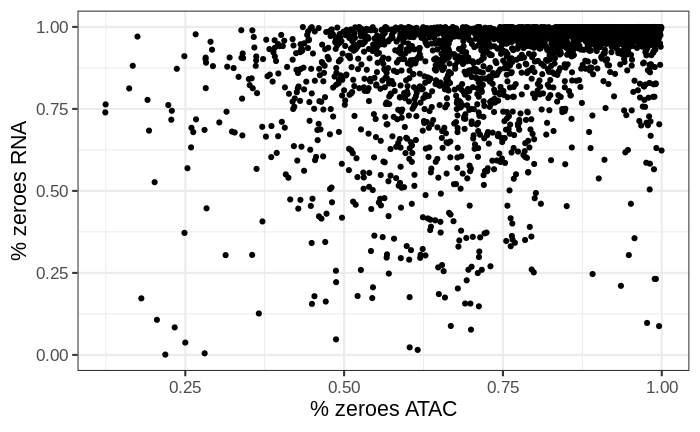

```r
frac0.rna <- apply(counts(f74.rna)[hvg.rna,],1, function(x) sum(x==0)/length(x))
frac0.atac <- apply(counts(f74.atac)[hvg.rna,],1, function(x) sum(x==0)/length(x))
data.frame(no_0_atac = frac0.atac, no_0_rna = frac0.rna) %>%
  ggplot(aes(no_0_atac, no_0_rna)) +
  geom_point() +
  xlab("% zeroes ATAC") + ylab("% zeroes RNA")
```

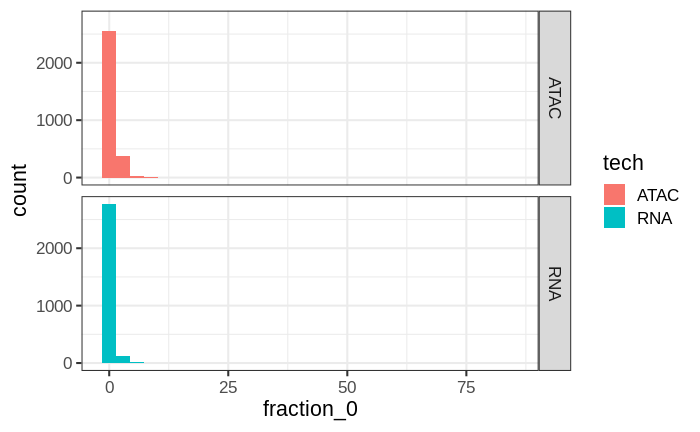

```r
data.frame(ATAC = sum.atac/ncol(counts(f74.atac)), RNA = sum.rna/ncol(counts(f74.rna))) %>%
  pivot_longer(cols = c("ATAC", "RNA"),names_to = "tech", values_to = "fraction_0") %>%
  ggplot(aes(fraction_0, fill=tech)) + geom_histogram(position="identity") +
  facet_grid(tech~.)
```

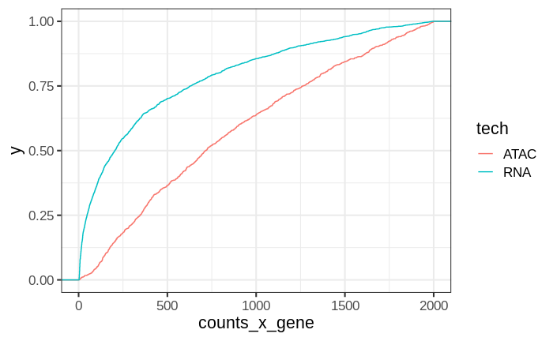

Are the HVGs more accessible than random genes?

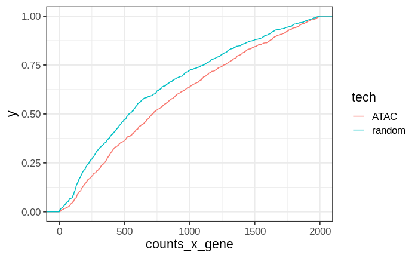

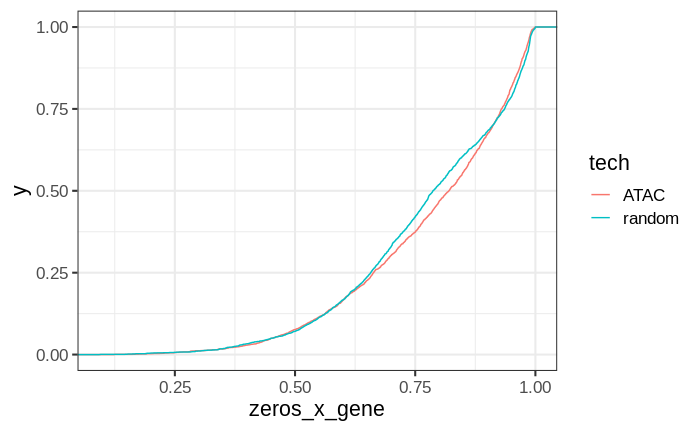

## Output clusters & UMAP coordinates for Daniel

```r
clusters_df <- f74.atac.seu@meta.data %>%
  as_tibble(rownames="cell") %>%
  select(cell, seurat_clusters)

umap_df <-
  f74.atac.seu@reductions$umap@cell.embeddings %>%
  as_tibble(rownames="cell")

full_join(clusters_df, umap_df) %>%
  write_csv("~/my_data/integrated_thymus/F74_ATAC_clustersUMAP_20191021.csv")
```